# Nothing to Lose

Teenagers Who Never Held the Vote Declined as Much as Those Who Lost It

Linlin Feng

19529296868@163.com

Shenzhen College of International Education

## Motivation

### The research question

- Democratic inclusion raises a question: how does exclusion from elections affect young people’s sense of being heard?
- Leininger et al. 2023 studied teenagers eligible for a state election but excluded from the next federal election.
- Did their attitudes change because they lost the vote, or because the election excluded them?

## Motivation

### Prior research and the contribution

- Voting experiences may shape later participation. Franklin 2004.
- Austrian voters under eighteen made choices of similar quality to older voters. Wagner et al. 2012.
- Efficacy and satisfaction with democracy measure different attitudes. Easton 1975 and Norris 2011.
- I make the original study’s appendix comparison with never-eligible teenagers central to the analysis.

## Political Context

### Federal rules and voting eligibility

Germany’s sixteen states set their election rules. In 2017, Schleswig-Holstein allowed voting at 16; Article 38 set 18 for federal elections.

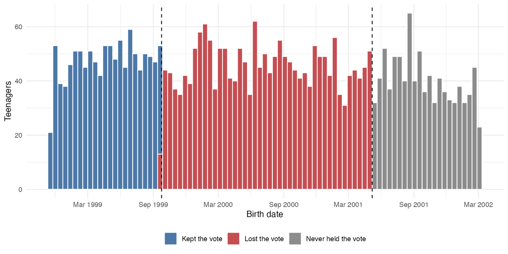

A natural experiment in eligibility across elections, with age as a competing explanation.

## Theoretical Framework

### Exclusion, withdrawal and age

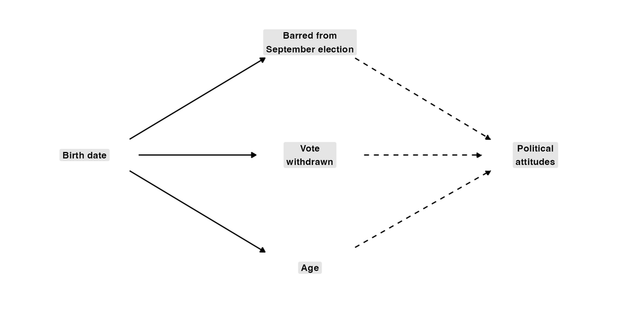

Solid arrows: links determined by birth date and electoral rules. Dashed arrows: possible effects on attitudes.

## Methodology

### Survey and outcome

- 3,897 teenagers answered Wave 1. Of these, 1,900 also answered Wave 2.
- The efficacy model uses 1,738 teenagers and 3,476 responses with usable answers in both waves.
- External efficacy ranges from 1 to 5. Higher scores mean feeling more heard.

## Methodology

### Difference-in-differences

- Compare each teenager’s answer before and after the federal election.
- Compare the size of those changes across voting groups.
- Person and wave effects account for stable personal differences and shared changes.

Key assumption: the groups would otherwise have followed similar trends.

## Findings

### Replicating the original comparison

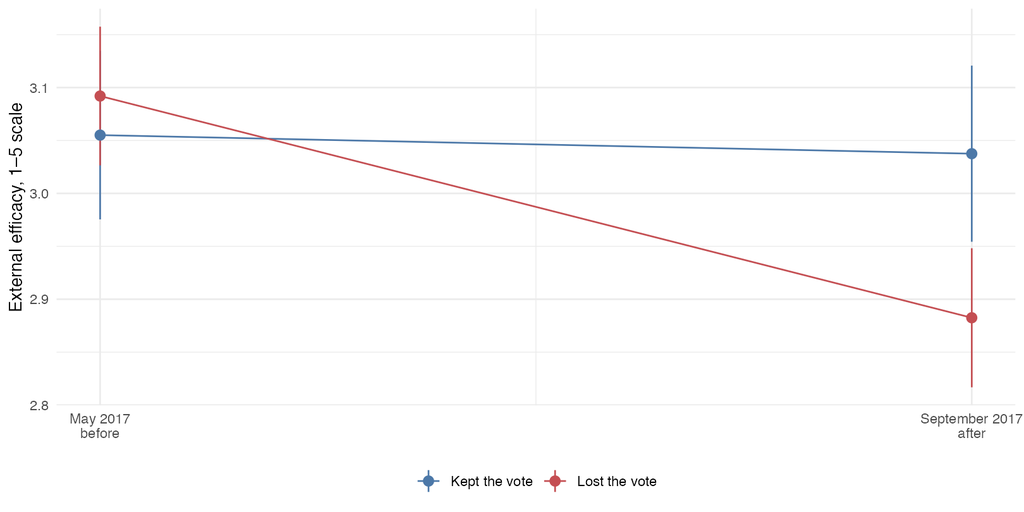

Descriptive averages of available answers. The model uses complete outcome pairs.

Lost versus kept: −0.208 points in the panel model.

## Findings

### Adding teenagers who never held the vote

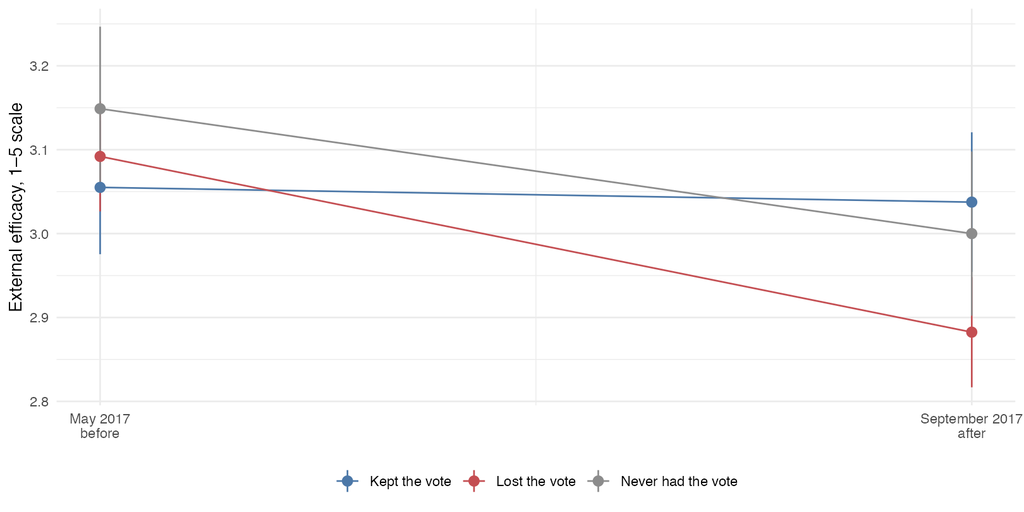

Descriptive averages of available answers. The model uses complete outcome pairs.

Never versus kept: −0.182 points in the panel model.

## Findings

### The additional withdrawal comparison

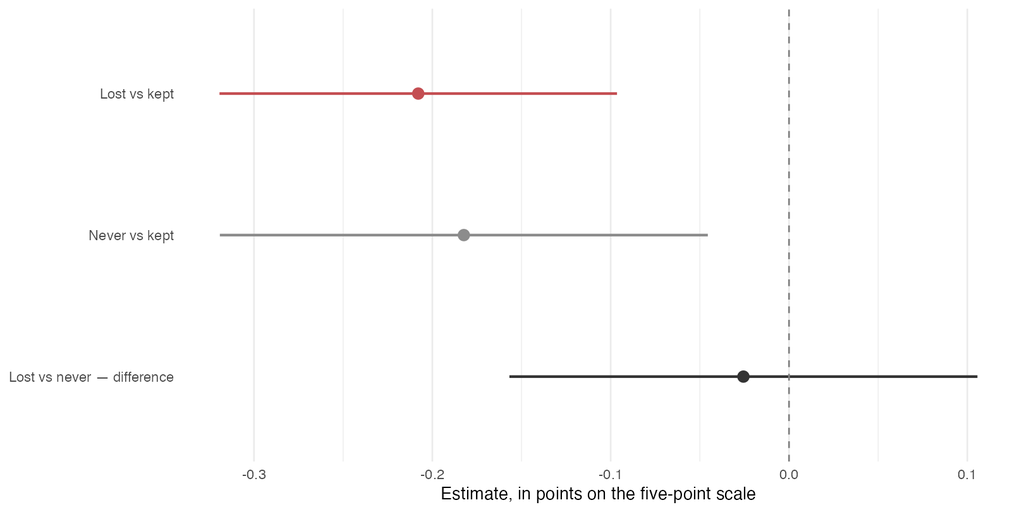

Lost versus never: −0.026 points; 95% interval −0.157 to +0.106.

## Findings

### What the confidence interval tells us

- An interval containing zero does not prove no effect. Rainey 2014.
- It rules out an additional decline as large as 0.208 points.
- It still allows a smaller decline, including roughly half that size.

## Findings

### Satisfaction and anger

| Comparison | Estimate | Standard error | p-value |
| --- | --- | --- | --- |
| Lost vs kept | −0.126 | 0.046 | 0.006 |
| Never vs kept | −0.023 | 0.055 | 0.683 |
| Lost vs never | −0.104 | 0.053 | 0.052 |

The anger gap falls from +0.424 to +0.078 points after adjusting for age.

## Discussion

### Limits to the comparison

- The never-eligible group was 1.23 years younger. Adolescent attitudes can develop differently. Eckstein et al. 2012.
- Only one pre-election wave is available, so earlier trends cannot be compared.
- About 49% returned for Wave 2. The lost group was 6.7 percentage points less likely to return than the kept group.

## Conclusion

### The decline does not isolate withdrawal

- Teenagers who lost the vote and those who never held it declined by similar amounts.
- Exclusion fits this pattern as well as withdrawal, while smaller withdrawal effects remain possible.
- Future research needs more pre-election waves and evidence from other settings.

## Thank you

### Questions and discussion

19529296868@163.com

yanlinfeng123.github.io

[Read the paper](https://yanlinfeng123.github.io/research/nothing-to-lose.html)

## References

### Voting rights and political support

Leininger et al. 2023. Temporary Disenfranchisement: Negative Side Effects of Lowering the Voting Age. American Political Science Review 117: 355–361. doi:10.1017/S000305542200034X.

Franklin. 2004. Voter Turnout and the Dynamics of Electoral Competition in Established Democracies Since 1945. Cambridge University Press.

Easton. 1975. A Re-assessment of the Concept of Political Support. British Journal of Political Science 5: 435–457.

Norris. 2011. Democratic Deficit: Critical Citizens Revisited. Cambridge University Press.

## References

### Youth participation and interpretation

Wagner, Johann and Kritzinger. 2012. Voting at 16: Turnout and the Quality of Vote Choice. Electoral Studies 31: 372–383. [doi:10.1016/j.electstud.2012.01.007](https://doi.org/10.1016/j.electstud.2012.01.007).

Eckstein, Noack and Gniewosz. 2012. Attitudes toward Political Engagement and Willingness to Participate in Politics: Trajectories throughout Adolescence. Journal of Adolescence 35: 485–495. [doi:10.1016/j.adolescence.2011.07.002](https://doi.org/10.1016/j.adolescence.2011.07.002).

Rainey. 2014. Arguing for a Negligible Effect. American Journal of Political Science 58: 1083–1091. [doi:10.1111/ajps.12102](https://doi.org/10.1111/ajps.12102).